# Data dimensionality reduction

Dr Irina Chis Ster

21/02/2021

# PROCESSING COMPLEX DATA - A START

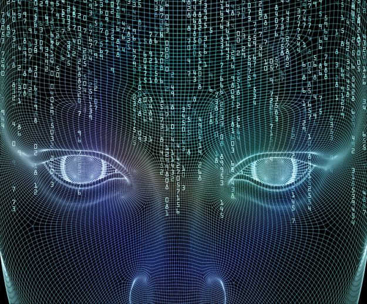

# Dimensionality reduction

- **Data** **Dimensionality** in statistics = many attributes a data set has.
- Example: hospital data
  - Demographics (age, gender, ethnicity, birth circumstances,..)
  - Social characteristics (habitat, poverty index, employment…)
  - Lifestyle elements (nutrition habits, exercise intake, etc.)
  - Environmental factors (geographical location)
  - Disease occurrence, death, etc.
- These **data** are still structured and could be represented in a spreadsheet, with one column representing a **dimension**.
- **High Dimensional** means that the number of dimensions are very high - managing and making sense of them becomes very difficult.
  - Somewhat counter-intuitive - we always want more data
  - This is a different setting from that of hypothesis testing and sits on the exploratory side of the analytical methodologies
- **Reduction of dimensionality** means to simplify understanding of data, either numerically or visually whilst maintaining its integrity.
  - To reduce dimensionality means combining related data into groups through rescaling variables of different magnitudes an into fewer components
  - Throwing away data - not a solution
- Why do we need to do this?
  - **The more dimensions you add to a data set**
    - **the more difficult it becomes to predict certain quantities**
    - the more difficult to visualize
  - Predictive models - parsimony. That is they should contain a minimum number of predictors yet explaining most of the variability in the outcome
  - No matter how complex an epidemiological/biological process -only the most important signals in the data can be robustly disentangled
- The number of features can exceed the number of observations.
- Reducing the complexity to a few dimensions, we can then plot the data and untangle its intrinsic characteristics, summarize and learn from.

## DIMENSIONALITY REDUCTION - NO CHERRY PICKYNG

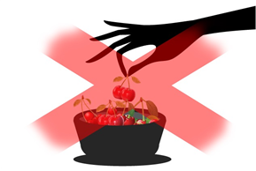

- What to do about it? Is discarding information a solution?
- Trade-off between complexity and simplicity
- Algorithms for extracting a set of “uncorrelated” principal variables and reduce the complexity of the data
- This is not done either randomly or by “choosing” some of the original variables
- New, “unrelated, uncorrelated” variables as functions of the old features are rather constructed.
- Tools available in R

### Linear algebra - MATRIX reloaded

[figure not shown]

- At the centre of all data simplification procedures - **A MATRIX**
- A dataset as a spreadsheet can be thought as a matrix with data variables as columns – elements easy to store and access using their positions (ROW, COLUMN)
- BUT – this is NOT the matrix we refer to
- A novel associated matrix to the original data based on data variability is constructed
- No scaremongering: R does everything for you!

### **The concept of normalizing or standardizing ONE variable**

- Data are of various magnitudes (example: age, blood concentrations, income, etc.)
- Let’s assume that X is a continuous variable with n observations $X=(x_1, x_2, ..., x_n)$
  - The mean $\mu=\frac{x_1+x_2+ ...+x_n}{n}$
  - The variance $Var(X)=\frac{(x_1-\mu)^2+(x_2-\mu)^2+...+(x_n-\mu)^2}{n-1}$
  - The $SD=\sqrt{Var(X)}$
  - $X_{standard}=\frac{(x_1-\mu, x_2-\mu, ..., x_n-\mu)}{SD}$
  - $x_1\longrightarrow\frac{x_1-\mu}{SD}$ -each components is transformed into the number of standard deviations from the mean

### Two or more variables

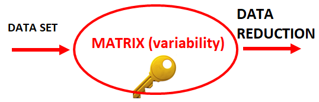

## Principal Component Analysis - an informal explanation

- PCA is a meaningful name: finds the principal components of the data
- PCA – the components explaining most of the variability in the data - relies on fairly hard core mathematics - matrices operations. All done by R!
- Involves paired concepts such as
  - *eigenvector* - a direction
  - *eigenvalue* - a number quantifying how much variance there is in the data in its corresponding eigenvector direction
  - Concepts associated to a square matrix and hence to the variability matrix
- Principal components
  - The underlying structure of the data
  - The directions of largest variance
- They are automatically done in R - inbuilt functions

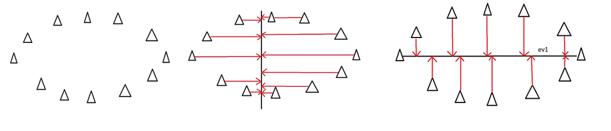

## PCA -Variability processing of the data

- A dimension-reduction tool that can be used to reduce a large set of variables to a small set that still contains most of the information initially contained in the large set.
- A mathematical procedure that *transforms a number of (possibly) correlated variables* into a (smaller) number of *uncorrelated variables* called *principal components.*
- **Algorithm:** The first principal component *accounts for as much of the variability* in the data as possible, and **each succeeding component accounts for as much of the remaining variability** as possible.

## PCA EXAMPLES IN R

### SIMULATED DATA EXAMPLE

- This routine
  - builds a matrix in R,
  - simulate a normal distribution and
  - a bivariate normal distribution.
- The simulated data would consist of the components of the bivariate distribution, i.e. two continuous variables relatively highly correlated.

```r
## The matrix below is required to specify the multivariate normal distribution
Sigma<-matrix(c(20,3,3,1),2,2)
Sigma

## set the same seed for the simulations to obtain similar numbers
set.seed(54321)

##generate/simulate a normal distribution with mean 20 and standard deviation=5)
norm <- rnorm(1000, 20, 5)
sum<-summary(norm)
sum
sd(norm)
hist(norm)

#Generate two variables sampled from a bivariate normal distribution with means 50 and 10, variances 10 and 2 and
#correlation 0.67 which is calculated from the simulated data)
sim.data <- mvrnorm(n=100, mu = c(50,10), Sigma =  matrix(c(10,3,3,2),2,2), empirical = T)

##store the data in an object
sim.data <- data.frame(sim.data)
##visualize the data frame
sim.data

##correlation - calculate
cor(sim.data$X1 ,sim.data$X2 , method = c("pearson"))

##visualize the bivariate distribution

# Calculate kernel density estimate
bivn.kde <- kde2d(sim.data[,1], sim.data[,2], n = 50)   # from MASS package

# Contour plot overlayed on heat map image of results - a plane representation of what is actually a Mexican hat
image(bivn.kde)       # from base graphics package
contour(bivn.kde, add = TRUE)     # from base graphics package
```

[output not shown]

- We use these data to exemplify the two directions of variability spread. This routine produces and plots the two directions which indicate the spread of the data (eigenvalues)

```r
#2-dimensional plot of the data
names(sim.data)
sim.data
#Create scatter plot of variable 1 vs. variable 2
plot(scale(sim.data$X1, scale= TRUE), scale(sim.data$X2, scale = TRUE), ylab = "Var2", xlab = "Var1", asp = 1, cex.lab=1.5, cex.axis = 1.5)


#Plot the eigenvectors of the correlation matrix of var1 and var2, showing the direction of the largest and second largest variance
#Create them
vecs <- eigen(cor(sim.data[,1:2]))$vectors
vals <- eigen(cor(sim.data[,1:2]))$values

#the eigenvectors
vals


##create arrows to show the directions of the eigenvectors
arrows(0,0, sqrt(vals[1])*vecs[1,1], sqrt(vals[1])*vecs[2,1], length = 0.1, lwd = 2, col = "red")
arrows(0,0, sqrt(vals[2])*vecs[1,2], sqrt(vals[2])*vecs[2,2], length = 0.1, lwd = 2, col = "blue")
```

[output not shown]

- This routine shows how much of the variability in the data is represented in PCA components

```r
#Perform PCA on the two variables based on correlation (scale. = TRUE)
pca.v12 <- prcomp(sim.data[,1:2])
summary(pca.v12)
#Plot scores on PC1 vs. PC2
plot(pca.v12$x[,1], pca.v12$x[,2], xlab = "PC1 (91.7%)", ylab = "PC2 (8.3%)", ylim = c(-1.5,1.5), cex.lab=1.4, cex.axis=1.4)

plot(pca.v12) ##visualize PC loadings as bars
plot(pca.v12,type="lines") ## different way of visualizing
```

[output not shown]

- We add more variables to the data and re-run the PCA analysis

```r
#Generate additional two variables sampled from a bivariate normal distribution with means 110 and 135, variances 20 and 33 and correlation 0.856
sim.data1 <- mvrnorm(n=100, mu = c(110,135), Sigma =  matrix(c(20,22,22,33),2,2), empirical = T)
sim.data1 <- data.frame(sim.data1)

#Add the additional two variables to the first two in one data frame
sim.data$X3 <- sim.data1$X1
sim.data$X4 <- sim.data1$X2
sim.data

#Perform PCA on the small data set using the prcomp function based on the standardized data matrix (correlation and not covariance)

pca.data <- prcomp(sim.data, scale. = TRUE)
pca.data
#Create a Scree plot and Horn's parallel analysis to decide how many components to retain
plot(c(1,2,3,4), pca.data$sdev^2, ylab = "Eigenvalue", xlab = "Principal component", type = "o", lwd = 1.5, pch = 16, col = "blue", xaxt = "n", xlim = c(0.8, 4.2), ylim = c(0, 2), cex.lab=1.3, cex.axis=1.3)
axis(1, at=c(1,2,3,4), labels=c(1,2,3,4), cex.lab=1.3, cex.axis=1.3)
```

[output not shown]

### REAL DATA EXAMPLE

Parkinson’s disease case study variables – a series of highly correlated brain measurements

- **Top of SN Voxel Intensity Ratio** - obtained by averaging five random points, taken from the left side within the axial slice, from the nigrosome-1 region. Five random points from the ventral medial portion of the substantia nigra (a layer of deeply pigmented grey matter situated in the midbrain and containing the cell bodies of a tract of dopamine-producing nerve cells whose secretion tends to be deficient in Parkinson’s disease) within the slice of interest are averaged. The mean for the nigrosome-1 was divided over the mean for the other ROI’s to generate the Top of SN Voxel Intensity ratios both on the left and right side.
- **Side of SN Voxel Intensity Ratio -** obtained by averaging five random points, taken from the left side within the axial slice, from the nigrosome-1 region. Again, five random points from the outer swallow tail of the substantia nigra within the slice of interest are averaged on the left and right side
- **The Movement Disorder Society (MDS)-Unified Parkinson’s Disease Rating Scale (MDS-UPDRS) includes**
  - Part I (Non-motor Experiences of Daily Living);
  - Part II (Motor Experiences of Daily Living);
  - Part III (Motor Examination);
  - Part IV (Motor Complications) which was excluded as it was only conducted for PPMI subjects who had started PD medication.

### DATA SUMMARY

- Read in the data, summary the variables

```r
#Read the data
pd_data<-read.table("ParkinsonProgressionMarkers.txt",  sep="\t", header=TRUE)
## display the first 10 lines for a flavour
pd_data[1:10, ] ##show the first 10 lines
dim(pd_data)
names(pd_data)
summary(pd_data)
```

[output not shown]

- Calculate the variance covariance matrix associated with these data

```r
##Find the covariance matrix S of the data. The id column is obviously not included.
S <- cov(pd_data[,2:7])
##display S
S
```

```
                                 Top_of_sn_voxel_intensity_ratio Side_of_sn_voxel_intensity_ratio     Part_ia    Part_ib     Part_ii    Part_iii
Top_of_sn_voxel_intensity_ratio                       0.07159030                       0.01839495 -0.04129174 -0.2616217 -0.05291107  -0.9722435
Side_of_sn_voxel_intensity_ratio                      0.01839495                       0.01576953 -0.04121891 -0.2021246 -0.21459139  -0.7030053
Part_ia                                              -0.04129174                      -0.04121891  2.31439394  2.7102273  3.47727273   9.5265152
Part_ib                                              -0.26162167                      -0.20212459  2.71022727 13.1477273  9.53977273  26.1619318
Part_ii                                              -0.05291107                      -0.21459139  3.47727273  9.5397727 20.58522727  31.0568182
Part_iii                                             -0.97224345                      -0.70300534  9.52651515 26.1619318 31.05681818 114.7462121
```

- Calculate and display the eigenvalues and the eigenvectors

```r
##The total variance is equal to the sum of the eigenvalues of S.
sum(diag(S))

##Compute the eigenvalues and corresponding eigenvectors of S.
s.eigen <- eigen(S)
s.eigen
```

[output not shown]

- The eigenvectors represent the principal components of S. The eigenvalues of S are used to find the proportion of the total variance explained by the components.

```r
##The eigenvectors represent the principal components of S. The eigenvalues of S are used to find the proportion of the total variance explained by the components.
for (s in s.eigen$values) {
  print(s / sum(s.eigen$values))
}

plot(s.eigen$values, xlab = 'Eigenvalue Number', ylab = 'Eigenvalue Size', main = 'Scree Graph')
lines(s.eigen$values)
```

[output not shown]

- The elements of the eigenvectors of S are the ‘coefficients’ or ‘loadings’ of the principal components.

```r
##The elements of the eigenvectors of S are the 'coefficients' or 'loadings' of the principal components.
s.eigen$vectors
```

```
             [,1]          [,2]         [,3]        [,4]        [,5]         [,6]
[1,] -0.007460885 -0.0182022094  0.016893310  0.02071858  0.97198981 -0.232667534
[2,] -0.005800877  0.0006155263  0.004186175  0.01552970  0.23234859  0.972482086
[3,]  0.080839361 -0.0600389904 -0.027351225  0.99421646 -0.02352324 -0.009618586
[4,]  0.229718933 -0.2817718054 -0.929463536 -0.06088782  0.01466135  0.003019007
[5,]  0.282109618 -0.8926329596  0.344508308 -0.06772403 -0.01764367  0.006061773
[6,]  0.927911126  0.3462292153  0.127908417 -0.05068855  0.01305167  0.002456373
```

- The first two principal components are thus a linear combination of these loadings (or weights).

```r
pd_data.pca <- prcomp(pd_data[,2:7])
pd_data.pca

##The summary method of prcomp() also outputs the proportion of variance explained by the components.
summary(pd_data.pca)

screeplot(pd_data.pca)
screeplot(pd_data.pca, type="lines")
```

[output not shown]

- Interpretation: most of the variability in the data (almost 95%) is explained by the first two components.

### SAME AS ABOVE BUT CALCULATE THE CORRELATION MATRIX

- If the units of measurements are greatly different the correlation matrix is recommended

```r
R <- cor(pd_data[,2:7])
R
```

```
                                 Top_of_sn_voxel_intensity_ratio Side_of_sn_voxel_intensity_ratio    Part_ia    Part_ib     Part_ii   Part_iii
Top_of_sn_voxel_intensity_ratio                       1.00000000                        0.5474722 -0.1014419 -0.2696629 -0.04358546 -0.3392179
Side_of_sn_voxel_intensity_ratio                      0.54747218                        1.0000000 -0.2157587 -0.4438992 -0.37663878 -0.5226128
Part_ia                                              -0.10144192                       -0.2157587  1.0000000  0.4913169  0.50378157  0.5845831
Part_ib                                              -0.26966294                       -0.4438992  0.4913169  1.0000000  0.57987562  0.6735584
Part_ii                                              -0.04358546                       -0.3766388  0.5037816  0.5798756  1.00000000  0.6390134
Part_iii                                             -0.33921789                       -0.5226128  0.5845831  0.6735584  0.63901337  1.0000000
```

```r
##Find the eigenvalues and eigenvectors of the R matrix.
r.eigen <- eigen(R)

##As with the covariance matrix, we can compute the proportion of total variance explained by the eigenvalues.

for (r in r.eigen$values) {
  print(r / sum(r.eigen$values))
}
```

```
[1] 0.5327121
[1] 0.2036444
[1] 0.09501723
[1] 0.06989084
[1] 0.05393633
[1] 0.04479903
```

- What is readily noticeable is the first eigenvalue accounts for 53% of total variance compared with 87% of the variance of the S matrix. The first two components of R only account for 73% of total variance while the last two components have little significance. Thus, one may want to keep the first four components rather than the first two with the S matrix.

```r
##To perform principal component analysis using the correlation matrix using the prcomp() function, set the scale argument to TRUE. The default is false

pd_data.pca.scaled <- prcomp(pd_data[,2:7], scale = TRUE)
pd_data.pca.scaled
```

```
Standard deviations (1, .., p=6):
[1] 1.7878123 1.1053808 0.7550519 0.6475685 0.5688743 0.5184536

Rotation (n x k) = (6 x 6):
                                        PC1        PC2         PC3         PC4        PC5         PC6
Top_of_sn_voxel_intensity_ratio   0.2555204 0.71258160 -0.37323593  0.10487783 -0.4773991  0.22073170
Side_of_sn_voxel_intensity_ratio  0.3855208 0.47213741  0.35665530 -0.43312956  0.5581866  0.04564453
Part_ia                          -0.3825033 0.37288206  0.70992667  0.31993415 -0.2379855 -0.22728686
Part_ib                          -0.4597352 0.09803469 -0.11166513 -0.79389281 -0.2915572 -0.22647781
Part_ii                          -0.4251107 0.34167995 -0.46424924  0.26165338  0.5341197 -0.36505065
Part_iii                         -0.4976933 0.06258368  0.03872476 -0.01769982  0.1832790  0.84438179
```

```r
summary(pd_data.pca.scaled)
```

```
Importance of components:
                          PC1    PC2     PC3     PC4     PC5    PC6
Standard deviation     1.7878 1.1054 0.75505 0.64757 0.56887 0.5185
Proportion of Variance 0.5327 0.2036 0.09502 0.06989 0.05394 0.0448
Cumulative Proportion  0.5327 0.7364 0.83137 0.90126 0.95520 1.0000
```

- Interpretation of principal components is still a heavily researched topic in statistics, and although the components may be readily interpreted in most settings, this is not always the case
- One method of interpretation of the principal components is to calculate the correlation between the original data and each component.
- The PCs can then be interpreted based on which variables they are most correlated in either a positive or negative direction. The level at which the correlations are significant is left to the researcher. In other words depends on the research field.

## PCA WRAP UP

- Multivariate Analyses often starts out with data involving a substantial number of correlated variables.
- Only applicable to a range of continuous variables: it involves concepts such variances, covariances, correlations only applicable to continuous data
- (PCA) is a dimension-reduction tool that can be used to reduce a large set of variables to a small set that still contains most of the information in the large set.
- Principal component analysis (PCA) is a mathematical procedure that transforms a number of (possibly) correlated variables into a (smaller) number of uncorrelated variables called principal components.
- The first principal component accounts for as much of the variability in the data as possible, and each succeeding component accounts for as much of the remaining variability as possible.
- However, *PCA does not have inferential value*:
  - There is no p-value associated as there is no test.
  - It based on algebra rather than probabilities.
  - The concept does not involve dependent/response/statistical outcome
  - A method to find out where the variability in the data lies
  - Exploring large data, digging large data
- *The confirmatory part of a research starts after PCA* - understanding whether newly derived uncorrelated variables associate with an outcome